# hw5_geneFlow_divergenceTimes

Daisy Fry-Brumit

2022-11-03

## Part One: Use ASTRAL to Get a Species Tree

### Question 1: Provide the plot of your ASTRAL tree with posterior probability values at each node. Make sure the tree is clearly labeled and readable. (5 pts)

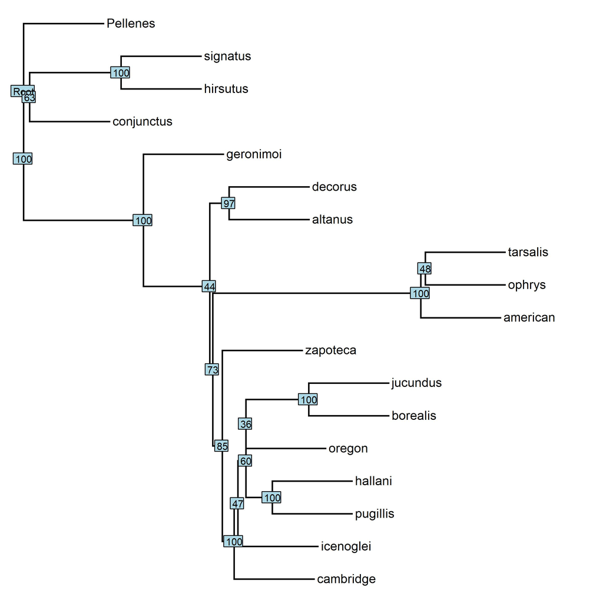

### Question 2: Provide your Density Tree plot. Based on this plot, would you say there is a lot of phylogenetic incongruence, or only a little? (2 pts)

Based on the following plot, I’d say that there’s a lot of incongruence here. The outgroup and two closest related taxa look fine, but everything else is messy.

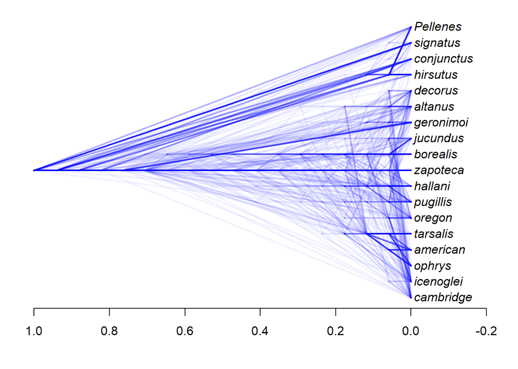

## Part Two: Using SNPs to Test for Gene Flow

### Question 3: Provide the plot of your SVDQuartets tree (You do not need to worry about node labels since there was no bootstrapping). (2 pts)

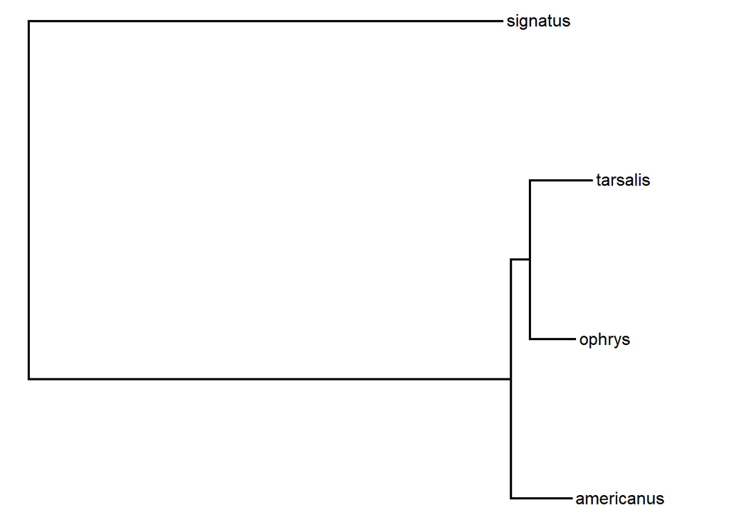

### Question 4: What are your species assignments for P1, P2, and P3? (2 pts)

P1 - tarsalis

P2 - ophrys

P3 - americanus

```
##
## performing bootstrap....................................................................................................
## Sites in alignment = 50000
## Number of sites with ABBA pattern = 554
## Number of sites with BABA pattern = 321
##
## D raw statistic / Z-score =  0.2662857  /  8.453724
##
## Results from  1000 bootstraps
## SD D statistic = 0.03149922
## P-value (that D=0) =  0
```

### Question 5: Is there evidence of gene flow between any of these species? If yes, then which pair of species is exchanging genes? (3 pts)

raw D stat = 0.266

P(D = 0) = 2.22e-16

### Question 6: Copy and paste the lines of code you used to specify your substitution model, the linking/unlinking of partitions, and the rate prior. Please do NOT copy and paste all of your partition information (i.e. all of the charset lines)! (1 pt)

```
begin mrbayes;
    set autoclose=yes nowarn=yes;
    execute SpidersConcat.nex;
    charset loc51068=1-412;
    ...
    partition byLocus = ...
    lset nst=6 rates=propinv;
    prset applyto=(all) ratepr=variable;
    ...
    unlink statefreq=(all) revmat=(all) shape=(all);
    ...
```

### Question 7: Copy and paste the lines of code you used to set up all of the node dating constraints, calibrations, and priors. (5 pts)

```
    ...
    constraint Hb = 1-6 8-18;
    constraint clade1 = 17 6 12;
    constraint clade2 = 6 12;
    constraint clade3 = 1-4 8-11 13-16 18;
    constraint clade4 = 11 16 1 18 10 14 2 9;
    constraint clade5 = 16 1;
    constraint clade6 = 13 15 4;

    calibrate clade1 = truncatednormal(2.100,4.800,1.400);
    calibrate clade2 = truncatednormal(.500,3.250,1.300);
    calibrate clade4 = truncatednormal(1.700, 2.700, .500);
    calibrate clade5 = truncatednormal(1.000, 1.500, .250);

    prset topologypr = constraint(Hb, clade1, clade2, clade3, clade4, clade5, clade6);
    prset treeagepr = truncatednormal(2.500,5.000,1.200);
    prset brlenspr = clock:uniform;
    prset clockratepr = lognorm(-5.5,0.5);
    prset clockvarpr = igr;

    outgroup Pellenes;
    mcmc ngen=10000000 samplefreq=100 printfreq=1000 file=spiders_concat;
    sump relburnin=yes burninfrac=0.25;
    sumt relburnin=yes burninfrac=0.25;
end;
```

### Question 8: Provide your plot of the Habronattus phylogeny with divergence time estimates. (4 pts)

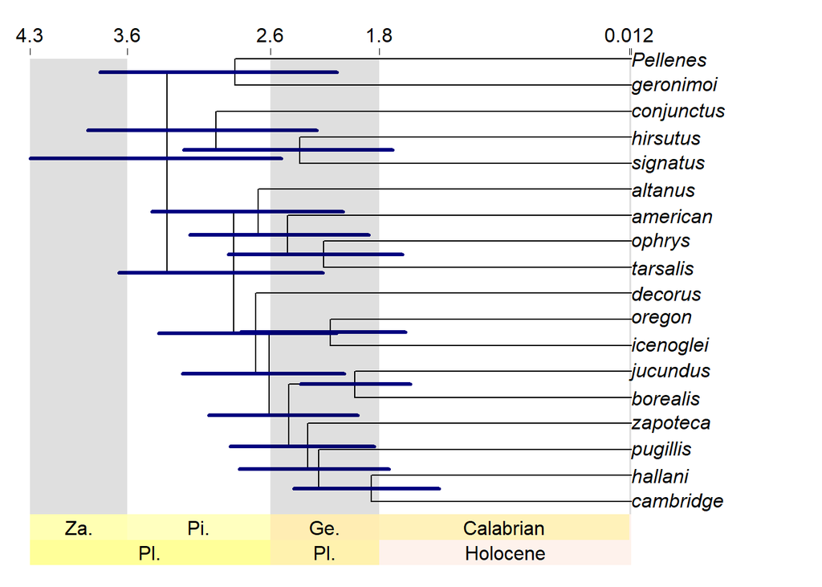